# What Makes A Board Game Good?

Kobe Sarausad

4/22/2021

In this report, I intend to uncover what factors make a quality board game. There are many factors that may affect a game’s quality, such as: game popularity, game mechanic, game category, game complexity, game age target, and playing time. I will be focusing on game mechanic, category, and complexity to determine how these factors can make a quality board game.

Each board game has many mechanics and categories in which they fit under. However, since there are so many mechanics and categories, I chose to focus on the main mechanic and category. That is the first mechanic and category that popped up in its description. This is to ensure that all board games can fit into a mechanic and a category.

Also, to measure the quality of the game, I used the user ratings as a way to see how people like the specific game. Higher rating = quality game. So let’s start looking at its popularity based on mechanic and category to determine if popularity might result in higher ratings.

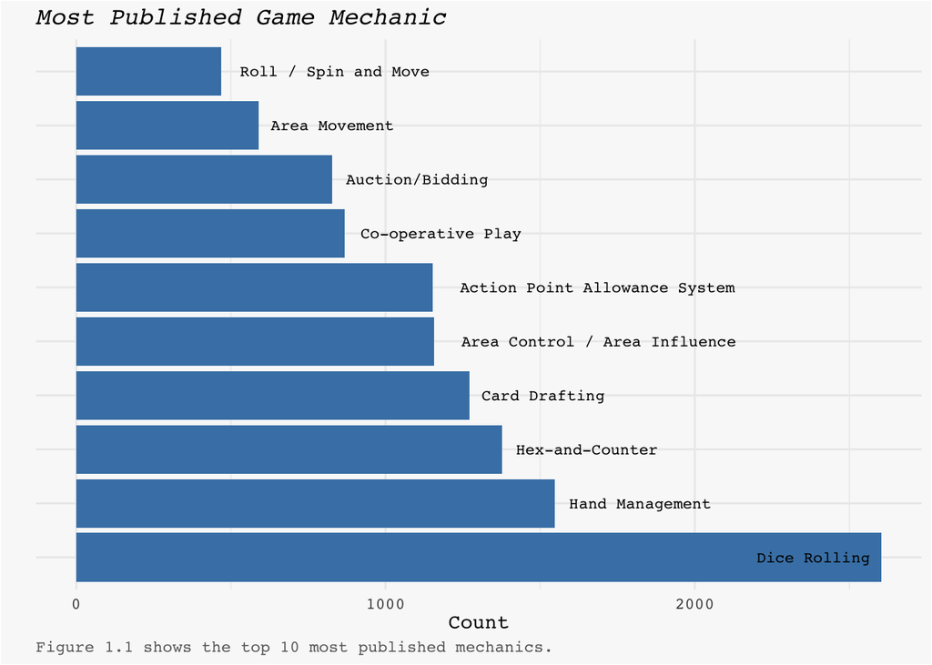

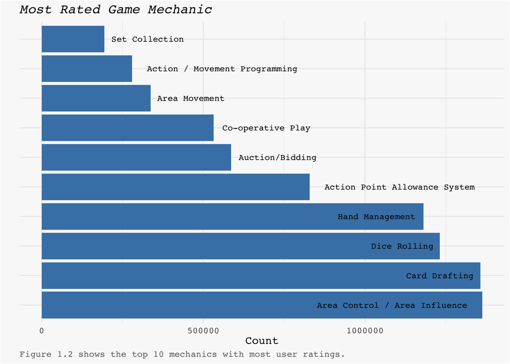

We can gauge the popularity of a board game mechanic by its number of published board games or the number of user rating for the board game. There are clear discrepancies between the two measurements as the most published mechanic is “Dice Rolling” but the most rated mechanic turns out to be “Area Control / Area Influence”, slightly beating “Card Drafting”. However, Both of these mechanics show up in the top 5 on both measurements.

Though the number of published games might hint at companies meeting the demand of the people, it is not a guarantee these games have a higher rating. But, let’s continue to evaluate “Dice Rolling” to see how it might perform.

Now, let’s checkout the popularity of the board game categories.

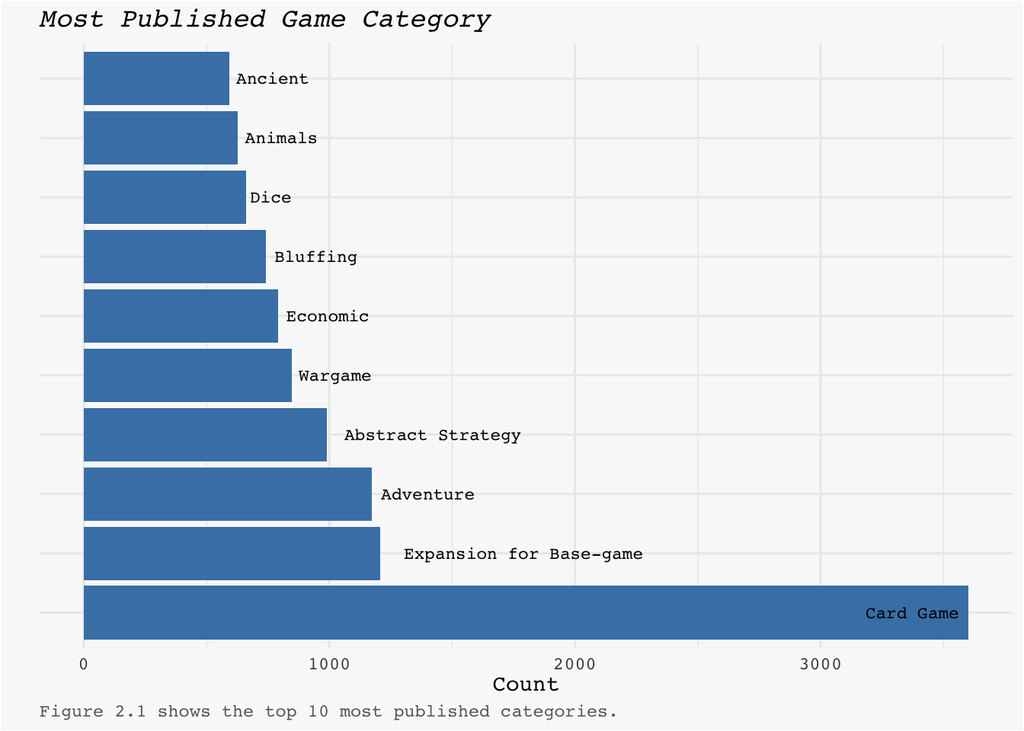

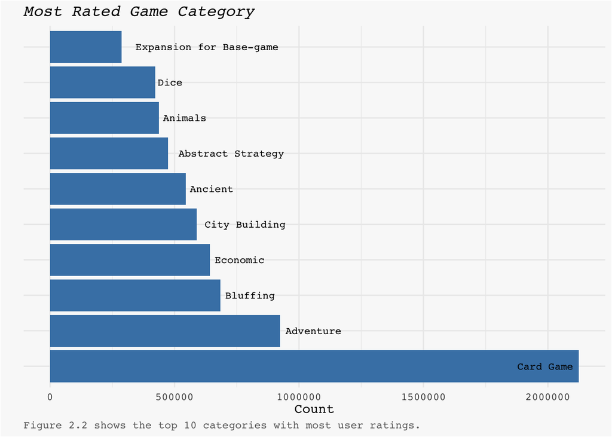

The “Card Game” category wins out here in both of the number of published games and number of user ratings. This category surely dominates all other categories unlike the other two mechanics. But does popularity mean higher ratings? Since popularity might not imply a game would be highly regarded, looking at the average rating will help us determine the a game’s quality. Thus, let’s see how the ratings differ among all the board games.

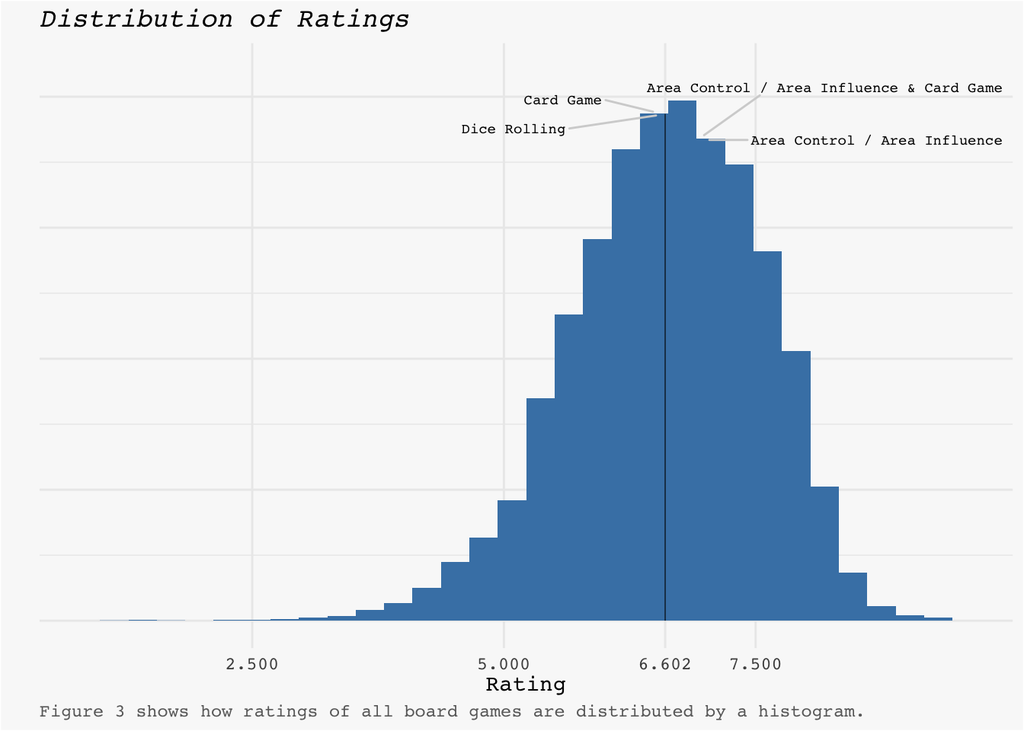

Here, we have the histogram of the average rating of all the board games. It will gives us an insight to how the ratings are distributed. But where do “Dice Rolling”, “Area Control / Area Influence”, and “Card Game” land? Turns out a board game that has a “Area Control / Area Influence” main mechanic and a “Card Game” main category scores a higher average rating than the overall average, which is around 6.602.

However, the most published games have a different tendency. “Dice Rolling” was the most published game mechanic but its rating remained at the overall mean. Same goes with “Card Game” which was the most published and rated game category. Overall, all of these relevant factors seemed to stay around the mean. So, we can’t guarantee that popularity will equate to higher ratings, though it might mean that the game will be around average.

So, let’s see which mechanics are rated highly.

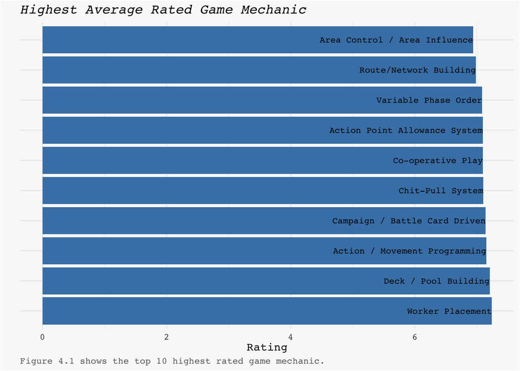

The most published game and the most user rated game failed to show up in the top 3 rated mechanics. “Area Control / Area Influence” actually shows up in the bottom but “Dice Rolling” failed to show up at all. But is this due to the another variable? Possibly complexity? Thus, the average complexity of each mechanic, category, and the combination of mechanic and category are computed to better uncover some trends, if any.

We will continue to see where “Dice Rolling” performs by plotting average complexity against average rating to to see if any relationships exist.

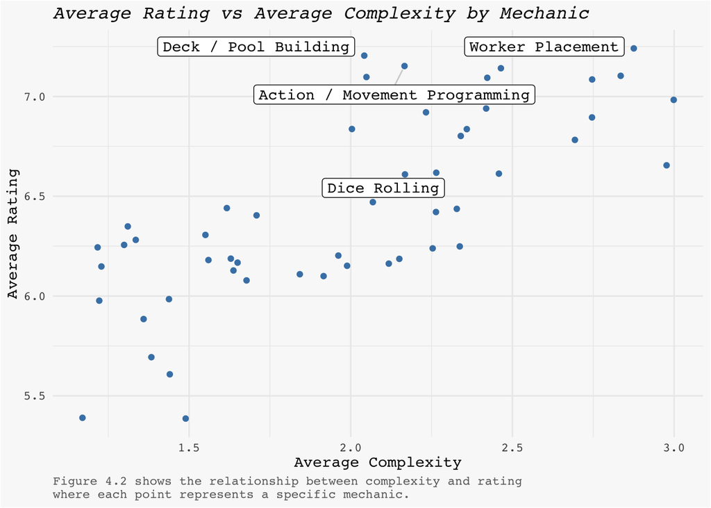

Interestingly, these complex games do possess a higher rating on average. I’ve labeled the top 3 highest rated mechanics and we can see that they are indeed pretty complex, especially “Worker Placement”. Having a lower complexity than the other two mechanics, “Deck / Pool Building” scores a high rating with a lower complexity (interesting finding!). We can also see that “Dice Rolling” ends up being in the middle of the pack so we can’t rule out popularity being one of the factors that influence ratings.

However, it is important to note that this plot is zoomed in to ensure that the difference of each point is visible (avoid overlapping). This actually does not change the overall trend as seen in the plot below, showing the overall trend.

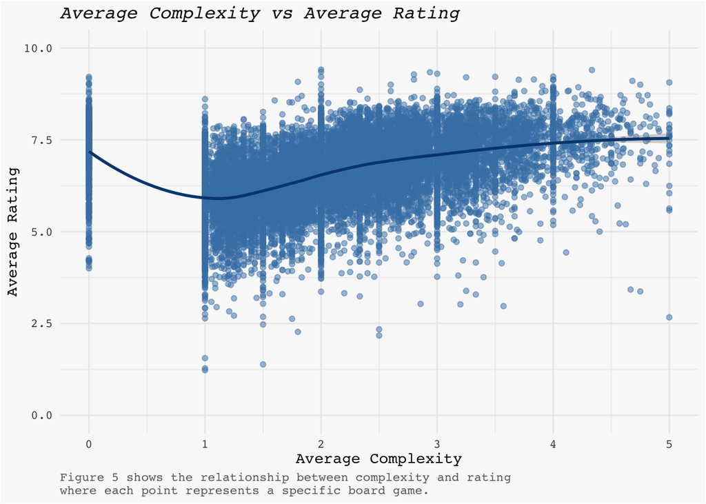

Here, we are able to study the trend of every single board game. We can observe that, like *Figure 4.2*, there is a relatively positive correlation between complexity and rating. Whilst it is seen that when the average complexity is 0, it does tend to have higher ratings. Likewise, though dipping in rating when complexity is between 0 and 1, it seems to recover after that.

But can the same be said for averages by category?

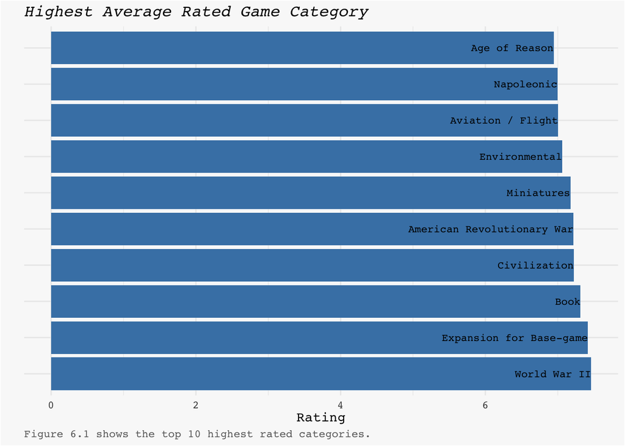

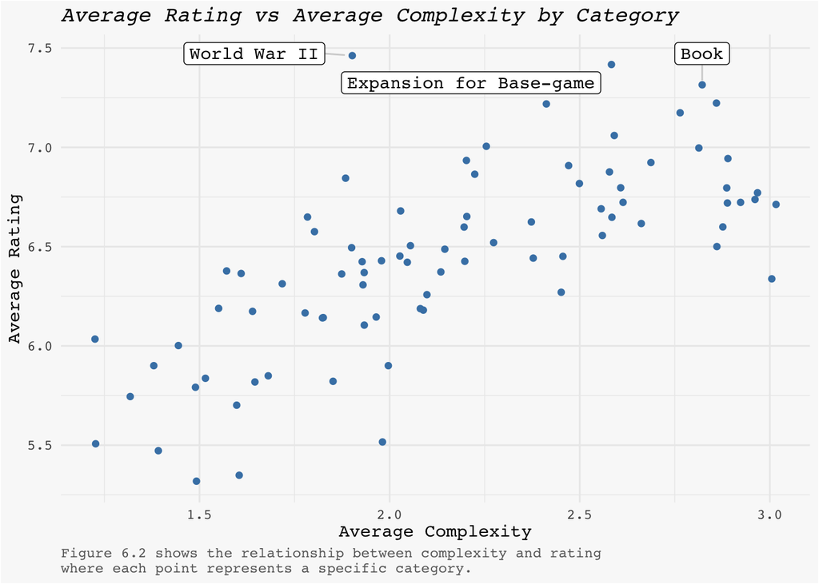

The trend does indeed continue for the game board’s category except for the “World War II” category. However, this category seemed to still score a high average score of 7.4619533, which was higher than the other two categories. Similar to what happened with the mechanic, some lower complexity board games can have a higher rating. But, the overall trend continues where higher complexity tends to increase rating.

But will the trend continue when looking at the best rated combination of mechanic and category?

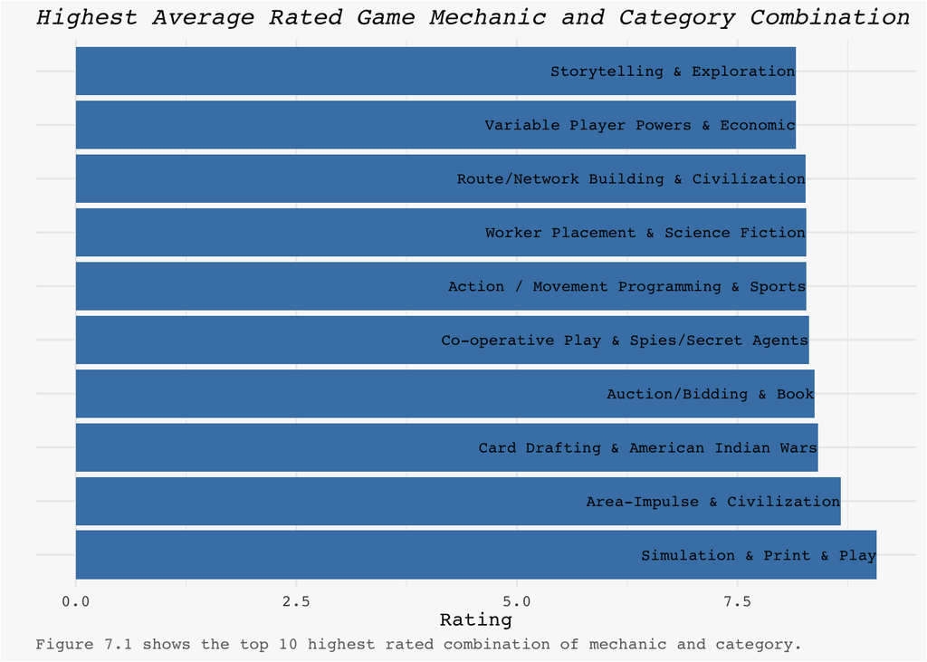

Comparing the combination of mechanic and category, the best performance was seen from the combination of Simulation / Print & Play. However, we can see that the combination of the best rated mechanic and category, “Worker Placement” & “World War II”, does not show up on the top 10 combinations. “Worker Placement” does show up once though, in a combination with “Science Fiction”. So, let’s see how complex these combinations might be.

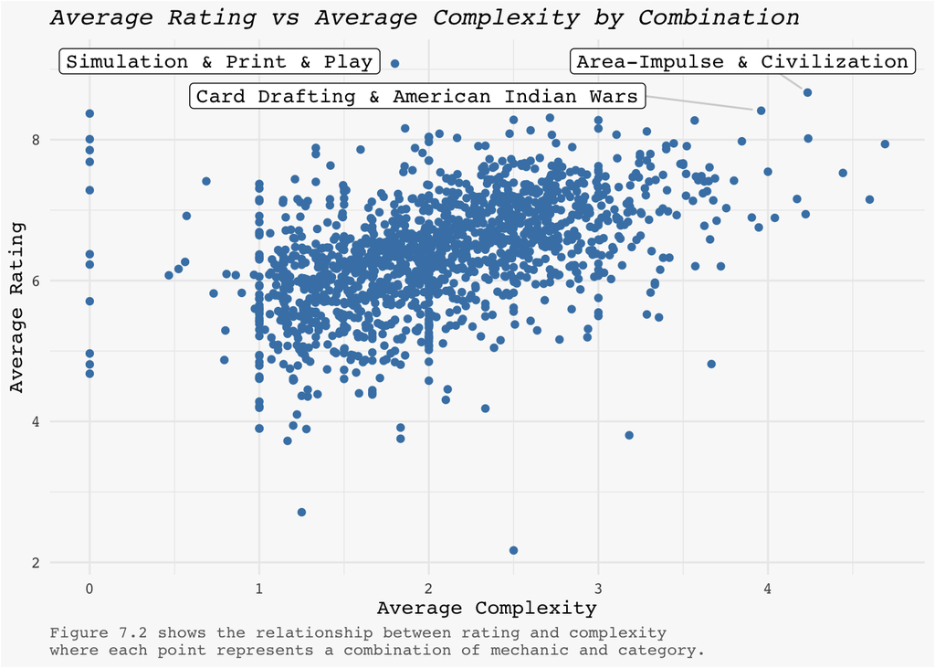

The top 3 performing mechanic and category combinations all have relatively high complexity, with “Simulation & Print & Play” seeming to perform well without high complexity. This is a trend we saw when just looking at how the single mechanic or category performs. We saw that even with low complexity, some games tend to veer off the trend and achieve higher ratings. But, these seem to be outliers as the overall trend points to a lower rating when complexity is low, while a higher complexity leads to a higher rating.

We saw similar trends in mechanic, category, and the combination of the two when comparing complexity and rating. Though the popularity of the game might not guarantee a high rated game, we can estimate how well they might perform by also looking at its mechanics, categories, and complexity. Some mechanics and categories might affect the average rating positively and some negatively. However, we did find the trend of more complex games being more quality, aka higher rated. Overall, the specific combinations of the mechanic, category, and complexity ultimately decides a board game’s ratings.

# Appendix: All code for this report

```r
# Load Packages and Data ----

# Load in necessary libraries
library(tidyverse)
library(splitstackshape)
library(ggrepel)

# Set code chunk options for all chunks
knitr::opts_chunk$set(message = FALSE, echo = FALSE, warning = FALSE)

# Read in data
bg_data_full <- read_csv("https://raw.githubusercontent.com/bryandmartin/STAT302/master/docs/Projects/project1_bgdataviz/board_game_raw.csv")

# Keep board games that were published after 1950 and have over 25 ratings
# Split the category and mechanic column into multiple columns
bg_data <- bg_data_full %>%
  filter(yearpublished >= 1950 & users_rated >= 25) %>%
  mutate(total_rating = users_rated * average_rating) %>%
  cSplit("category") %>%
  cSplit("mechanic")

# Drop all category columns except for first
bg_data <- bg_data %>%
  select(-c(category_02:category_14))

# Drop all mechanic columns except for first
bg_data <- bg_data %>%
  select(-c(mechanic_02:mechanic_18))

# Drop rows without a main category or mechanic
bg_data <- bg_data %>%
  filter(!is.na(category_01) & !is.na(mechanic_01))

# Rename category column
bg_data <- bg_data %>%
  rename("category" = "category_01")

# Rename mechanic column
bg_data <- bg_data %>%
  rename("mechanic" = "mechanic_01")

# Make new column for mechanic & category combined
bg_data <- bg_data %>%
  mutate(mec_cat = str_c(mechanic, " & ", category))

# Figure 1.1 ----

# Make a bar plot of the top 10 most published game mechanic
bg_data %>%
  group_by(mechanic) %>%
  tally() %>%
  top_n(10) %>%
  ggplot() +
  geom_bar(
    aes(x = reorder(mechanic, -n), y = n),
    stat = "identity",
    fill = "steelblue") +
  coord_flip() +
  geom_text(
    aes(x = reorder(mechanic, -n), y = n, label = (reorder(mechanic, -n)),
        hjust = ifelse(n > min(n) + mean(n), 1.1, -0.1)),
    family = "mono",
    size = 3) +
  theme_minimal() +
  theme(plot.title = element_text(face = "italic"),
        plot.caption = element_text(hjust = 0, color = "#696969"),
        axis.text.y = element_blank(),
        text = element_text(family = "mono"),
        plot.background = element_rect(fill = "#F9F9F9", color = "white")
  ) +
  labs(
    x = "",
    y = "Count",
    title = "Most Published Game Mechanic",
    caption = "Figure 1.1 shows the top 10 most published mechanics.")

# Figure 1.2 ----

# Don't wanna use scientific notation
options(scipen = 999)

# Make a bar plot of the top 10 most rated game mechanic
bg_data %>%
  group_by(mechanic) %>%
  summarize(n = sum(users_rated)) %>%
  top_n(10, n) %>%
  ggplot() +
  geom_bar(
    aes(x = reorder(mechanic, -n), y = n),
    stat = "identity", fill = "steelblue") +
  coord_flip() +
  geom_text(
    aes(x = reorder(mechanic, -n), y = n, label = (reorder(mechanic, -n)),
        hjust = ifelse(n > min(n) + mean(n), 1.1, -0.1)),
    family = "mono",
    size = 3) +
  theme_minimal() +
  theme(plot.title = element_text(face = "italic"),
        plot.caption = element_text(hjust = 0, color = "#696969"),
        axis.text.y = element_blank(),
        text = element_text(family = "mono"),
        plot.background = element_rect(fill = "#F9F9F9", color = "white")
  ) +
  labs(
    x = "",
    y = "Count",
    title = "Most Rated Game Mechanic",
    caption = "Figure 1.2 shows the top 10 mechanics with most user ratings.")

# Figure 2.1 ----

# Make bar plot for most published category
bg_data %>%
  group_by(category) %>%
  tally() %>%
  top_n(10) %>%
  ggplot() +
  geom_bar(
    aes(x = reorder(category, -n), y = n),
    stat = "identity",
    fill = "steelblue") +
  coord_flip() +
  geom_text(
    aes(x = reorder(category, -n), y = n, label = (reorder(category, -n)),
        hjust = ifelse(n > min(n) + mean(n), 1.1, -0.1)),
    family = "mono",
    size = 3) +
  theme_minimal() +
  theme(plot.title = element_text(face = "italic"),
        plot.caption = element_text(hjust = 0, color = "#696969"),
        axis.text.y = element_blank(),
        text = element_text(family = "mono"),
        plot.background = element_rect(fill = "#F9F9F9", color = "white")
  ) +
  labs(
    x = "",
    y = "Count",
    title = "Most Published Game Category",
    caption = "Figure 2.1 shows the top 10 most published categories.")

# Figure 2.2 ----

# Make plot for most rated category
bg_data %>%
  group_by(category) %>%
  summarize(n = sum(users_rated)) %>%
  top_n(10, n) %>%
  ggplot() +
  geom_bar(
    aes(x = reorder(category, -n), y = n),
    stat = "identity",
    fill = "steelblue") +
  coord_flip() +
  geom_text(
    aes(x = reorder(category, -n), y = n, label = (reorder(category, -n)),
        hjust = ifelse(n > min(n) + mean(n), 1.1, -0.1)),
    family = "mono",
    size = 3) +
  theme_minimal() +
  theme(plot.title = element_text(face = "italic"),
        plot.caption = element_text(hjust = 0, color = "#696969"),
        axis.text.y = element_blank(),
        text = element_text(family = "mono"),
        plot.background = element_rect(fill = "#F9F9F9", color = "white")
  ) +
  labs(
    x = "",
    y = "Count",
    title = "Most Rated Game Category",
    caption = "Figure 2.2 shows the top 10 categories with most user ratings.")

# Figure 3 ----

# Store total number of ratings and average rating for Dice Rolling mechanic
avg_rating_dice <- bg_data %>%
  filter(mechanic == "Dice Rolling") %>%
  summarize(
    num_ratings = mean(users_rated, na.rm = T),
    rate = mean(average_rating, na.rm = T))

# Store total number of ratings and average rating for Area Control / Area Influence mechanic
avg_rating_areac <- bg_data %>%
  filter(mechanic == "Area Control / Area Influence") %>%
  summarize(
    num_ratings = mean(users_rated, na.rm = T),
    rate = mean(average_rating, na.rm = T))

# Store total number of ratings and average rating for Card Game category
avg_rating_card <- bg_data %>%
  filter(category == "Card Game") %>%
  summarize(
    num_ratings = mean(users_rated, na.rm = T),
    rate = mean(average_rating, na.rm = T))

# Store total number of ratings and average rating for combination of Area Control / Area Influence mechanic and Card Game category
avg_rating_both <- bg_data %>%
  filter(
    mechanic == "Area Control / Area Influence" & category == "Card Game") %>%
  summarize(
    num_ratings = mean(users_rated, na.rm = T),
    rate = mean(average_rating, na.rm = T))
```

```r
# Names of variables
avg_ratings_name <- c("Dice Rolling",
                      "Area Control / Area Influence",
                      "Card Game",
                      "Area Control / Area Influence & Card Game")

# Store averages
avg_ratings_value <- c(
  avg_rating_dice$rate,
  avg_rating_areac$rate,
  avg_rating_card$rate,
  avg_rating_both$rate)

# Compute overall average ratings
avg_ratings_overall <- mean(bg_data$average_rating, na.rm = TRUE)

# Make histogram of the ratings
# Show mean with the vertical line
ggplot() +
  geom_histogram(data = bg_data, aes(x = average_rating), fill = "steelblue") +
  scale_x_discrete(limits = c(2.5, 5.0, round(avg_ratings_overall, 3), 7.5)) +
  ylim(c(0, 2100)) +
  geom_segment(
    aes(x = avg_ratings_overall, xend = avg_ratings_overall, y = 0, yend = 1934),
    size = 0.2) +
  geom_text_repel(
    aes(x = avg_ratings_value,
        y = c(1934, 1835, 1934, 1835),
        label = avg_ratings_name),
    nudge_x = c(-1.5, 2, -1, 2),
    nudge_y = c(-50, 0, 50, 200),
    size = 2.5,
    box.padding   = 0.35,
    point.padding = 0.5,
    segment.color = "lightgrey",
    family = "mono",
    max.overlaps = Inf) +
  theme_minimal() +
  theme(plot.title = element_text(face = "italic"),
        legend.position = "none",
        plot.caption = element_text(hjust = 0, color = "#696969"),
        axis.text.y = element_blank(),
        text = element_text(family = "mono"),
        plot.background = element_rect(fill = "#F9F9F9", color = "white")
  ) +
  labs(
    x = "Rating",
    y = "",
    title = "Distribution of Ratings",
    caption = "Figure 3 shows how ratings of all board games are distributed by a histogram.")

# Figure 4.1 ----

# Store top 10 mechanics by rating
top_10_mec <- bg_data %>%
  group_by(mechanic) %>%
  summarize(
    ratings = mean(users_rated, na.rm = T),
    rate = mean(average_rating, na.rm = T),
    n = n(),
    .groups = "drop") %>%
  top_n(10, wt = rate)

# Make bar plot of top 10 mechanics by rating
top_10_mec %>%
  ggplot() +
  geom_bar(
    aes(x = reorder(mechanic, -rate), y = rate),
    stat = "identity",
    fill = "steelblue") +
  coord_flip() +
  geom_text(
    aes(x = reorder(mechanic, -rate),
        y = rate,
        label = (reorder(mechanic, -rate)),
        hjust =  1),
    family = "mono",
    size = 3) +
  theme_minimal() +
  theme(plot.title = element_text(face = "italic"),
        plot.caption = element_text(hjust = 0, color = "#696969"),
        axis.text.y = element_blank(),
        text = element_text(family = "mono"),
        plot.background = element_rect(fill = "#F9F9F9", color = "white")
  ) +
  labs(
    x = "",
    y = "Rating",
    title = "Highest Average Rated Game Mechanic",
    caption = "Figure 4.1 shows the top 10 highest rated game mechanic.")

# Figure 4.2 ----

#Store the top 3 mechanics
top_mechanics <- top_10_mec %>%
  top_n(3, wt = rate) %>%
  pull(mechanic)

# Plot the average rating and average complexity for each mechanic
bg_data %>%
  group_by(mechanic) %>%
  summarize(rating = mean(average_rating),
            complexity = mean(average_complexity), n = n()) %>%
  ggplot(aes(x = complexity, y = rating, label = mechanic)) +
  geom_point(color = "steelblue") +
  geom_label_repel(
    aes(
      label = ifelse(mechanic %in% top_mechanics | mechanic == "Dice Rolling", as.character(mechanic), "")),
    box.padding   = 0.35,
    point.padding = 0.5,
    segment.color = "lightgrey",
    family = "mono") +
  theme_minimal() +
  theme(plot.title = element_text(face = "italic"),
        plot.caption = element_text(hjust = 0, color = "#696969"),
        text = element_text(family = "mono"),
        plot.background = element_rect(fill = "#F9F9F9", color = "white"),
        legend.position = c(0.8, 0.2),
        legend.title = element_blank()
  ) +
  labs(x = "Average Complexity",
       y = "Average Rating",
       title = "Average Rating vs Average Complexity by Mechanic",
       caption =
         "Figure 4.2 shows the relationship between complexity and rating\nwhere each point represents a specific mechanic.")

# Figure 5 ----

# Plot the average rating and average complexity for each individual game
bg_data %>%
  ggplot(aes(x = average_complexity, average_rating)) +
  geom_point(color = "steelblue", alpha = 0.5) +
  geom_smooth(method = "loess", color = "#00477F") +
  ylim(c(0, 10)) +
  xlim(c(0, 5)) +
  theme_minimal() +
  theme(plot.title = element_text(face = "italic"),
        plot.caption = element_text(hjust = 0, color = "#696969"),
        text = element_text(family = "mono"),
        plot.background = element_rect(fill = "#F9F9F9", color = "white")
  ) +
  labs(
    x = "Average Complexity",
    y = "Average Rating",
    title = "Average Complexity vs Average Rating",
    caption =
      "Figure 5 shows the relationship between complexity and rating\nwhere each point represents a specific board game.")
# Figure 6.1 ----

# Store top 10 categories by rating
top_10_cat <- bg_data %>%
  group_by(category) %>%
  summarize(ratings = mean(users_rated, na.rm = T),
            rate = mean(average_rating, na.rm = T),
            n = n(),
            .groups = "drop") %>%
  top_n(10, wt = rate)

# Plot barplot of top 10 categories by rating
top_10_cat %>%
  ggplot() +
  geom_bar(aes(x = reorder(category, -rate), y = rate),
           stat = "identity", fill = "steelblue") +
  coord_flip() +
  geom_text(
    aes(x = reorder(category, -rate),
        y = rate,
        label = (reorder(category, -rate)),
        hjust =  1),
    family = "mono", size = 3) +
  theme_minimal()  +
  theme(plot.title = element_text(face = "italic"),
        plot.caption = element_text(hjust = 0, color = "#696969"),
        axis.text.y = element_blank(),
        text = element_text(family = "mono"),
        plot.background = element_rect(fill = "#F9F9F9", color = "white")
  ) +
  labs(
    x = "",
    y = "Rating",
    title = "Highest Average Rated Game Category",
    caption = "Figure 6.1 shows the top 10 highest rated categories."
  )
# Figure 6.2 ----
```

```r
# Store top 3 categories
top_categories <- top_10_cat %>%
  top_n(3, wt = rate) %>%
  pull(category)

# Get average rating of World War II category games
ww2_score <- top_10_cat %>%
  filter(category == "World War II") %>%
  pull(rate)

# Get average of the other two category games
other_scores <- top_10_cat %>%
  filter(category != "World War II") %>%
  pull(rate)

# Plot the average rating and average complexity for each category
bg_data %>%
  group_by(category) %>%
  summarize(rating = mean(average_rating),
            complexity = mean(average_complexity), n = n()) %>%
  ggplot(aes(x = complexity, y = rating, label = category)) +
  geom_point(color = "steelblue") +
  geom_label_repel(
    aes(
      label = ifelse(category %in% top_categories, as.character(category), "")
    ),
    nudge_y = c(0, 0.2, 0.2),
    nudge_x = c(-0.2, 0, 0),
    box.padding   = 0.35,
    point.padding = 0.5,
    segment.color = "lightgrey",
    family = "mono") +
  theme_minimal() +
  theme(plot.title = element_text(face = "italic"),
        plot.caption = element_text(hjust = 0, color = "#696969"),
        text = element_text(family = "mono"),
        plot.background = element_rect(fill = "#F9F9F9", color = "white"),
        legend.position = c(0.8, 0.2),
        legend.title = element_blank()
  ) +
  labs(x = "Average Complexity",
       y = "Average Rating",
       title = "Average Rating vs Average Complexity by Category",
       caption =
         "Figure 6.2 shows the relationship between complexity and rating\nwhere each point represents a specific category.")

# Figure 7.1 ----

# Plot the barplot of the top 10 mechanic and category combinations
bg_data %>%
  group_by(mec_cat) %>%
  summarize(ratings = mean(users_rated, na.rm = T),
            rate = mean(average_rating, na.rm = T),
            n = n(), .groups = "drop") %>%
  top_n(10, wt = rate) %>%
  ggplot() +
  geom_bar(aes(x = reorder(mec_cat, -rate), y = rate),
           stat = "identity", fill = "steelblue") +
  coord_flip() +
  geom_text(
    aes(x = reorder(mec_cat, -rate),
        y = rate,
        label = (reorder(mec_cat, -rate)),
        hjust =  1),
    family = "mono", size = 3) +
  theme_minimal() +
  theme(plot.title = element_text(face = "italic"),
        plot.caption = element_text(hjust = 0, color = "#696969"),
        axis.text.y = element_blank(),
        text = element_text(family = "mono"),
        plot.background = element_rect(fill = "#F9F9F9", color = "white")
  ) +
  labs(
    x = "",
    y = "Rating",
    title = "Highest Average Rated Game Mechanic and Category Combination",
    caption =
      "Figure 7.1 shows the top 10 highest rated combination of mechanic and category.")

# Figure 7.2 ----

# Get top three combinations
top_combos <- bg_data %>%
  group_by(mec_cat) %>%
  summarize(ratings = mean(users_rated, na.rm = T),
            rate = mean(average_rating, na.rm = T),
            n = n(), .groups = "drop") %>%
  top_n(3, wt = rate) %>%
  pull(mec_cat)

# Plot each individual combinations' average complexity and average rating
bg_data %>%
  group_by(mec_cat) %>%
  summarize(rating = mean(average_rating, na.rm = T),
            complexity = mean(average_complexity, na.rm = T),
            n = n(), .groups = "drop") %>%
  ggplot(aes(x = complexity, y = rating, label = mec_cat)) +
  geom_point(color = "steelblue") +
  geom_label_repel(
    aes(label = ifelse(mec_cat %in% top_combos, as.character(mec_cat), "")),
    nudge_x = -1,
    box.padding = 0.35,
    point.padding = 0.5,
    segment.color = "lightgrey",
    family = "mono",
    max.overlaps = Inf) +
  theme_minimal() +
  theme(plot.title = element_text(face = "italic"),
        plot.caption = element_text(hjust = 0, color = "#696969"),
        plot.caption.position = "panel",
        text = element_text(family = "mono"),
        plot.background = element_rect(fill = "#F9F9F9", color = "white"),
        legend.position = c(0.8, 0.2),
        legend.title = element_blank()
  ) +
  labs(x = "Average Complexity",
       y = "Average Rating",
       title = "Average Rating vs Average Complexity by Combination",
       caption =
         "Figure 7.2 shows the relationship between rating and complexity\nwhere each point represents a combination of mechanic and category.")
```